# MTCARS MPG Explorer

Isi

2026-04-24

# Problem and Solution

`MTCARS MPG Explorer` is a small interactive Shiny app built for the Coursera course `Developing Data Products`.

Its goal is to turn the classic `mtcars` dataset into a simple tool for exploring fuel efficiency.

The app lets users:

- filter cars by horsepower
- compare automatic and manual transmission groups
- focus on selected gear counts
- visualize the relationship between car weight and fuel economy

# Why the App Is Useful

Fuel economy is not driven by one variable alone.

Instead of reading a static table, users can interactively explore how vehicle weight, horsepower, gears, and transmission type influence miles per gallon.

This makes the app useful for:

- learning exploratory data analysis with a familiar dataset
- understanding simple relationships in automotive performance data
- seeing how filters change both plots and summary statistics in real time

# Reproducible Evidence

The app uses the built-in `mtcars` dataset, so it is fully reproducible without external downloads.

The deployed Shiny app is available here:

https://img-mgt.shinyapps.io/mtcars-mpg-explorer/

```
##       mpg              hp              wt             gear
##  Min.   :10.40   Min.   : 52.0   Min.   :1.513   Min.   :3.000
##  1st Qu.:15.43   1st Qu.: 96.5   1st Qu.:2.581   1st Qu.:3.000
##  Median :19.20   Median :123.0   Median :3.325   Median :4.000
##  Mean   :20.09   Mean   :146.7   Mean   :3.217   Mean   :3.688
##  3rd Qu.:22.80   3rd Qu.:180.0   3rd Qu.:3.610   3rd Qu.:4.000
##  Max.   :33.90   Max.   :335.0   Max.   :5.424   Max.   :5.000
```

# Embedded R Code Example

One of the clearest patterns in `mtcars` is that heavier cars tend to have lower fuel economy.

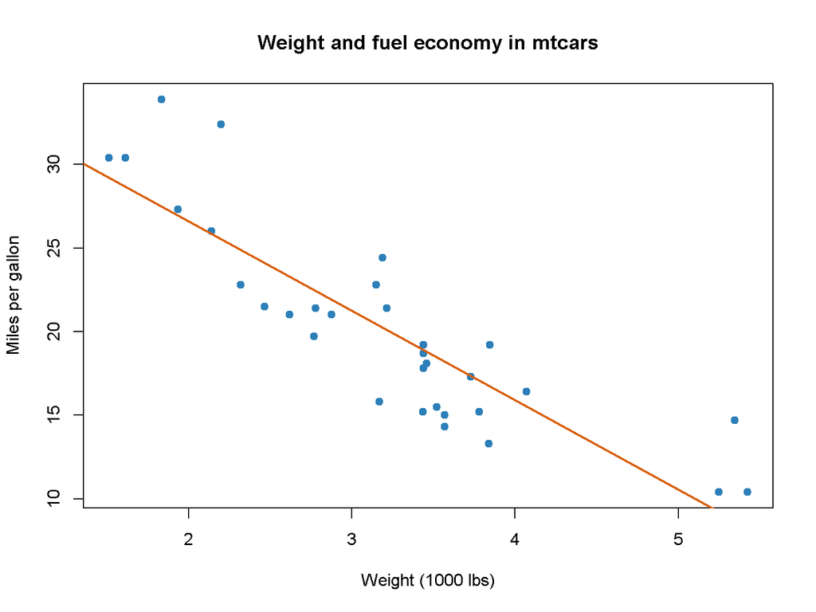

The regression line highlights the negative association between weight and MPG, which users can inspect interactively inside the app with filters and live summaries.